```
/content
/content/gdrive/MyDrive/Colab Notebooks/SEMESTRE_7/Modulo1/Mercurio
EvidenciaEstadistica_2.ipynb  mercurio.csv
```

# Reporte final de "Los peces y el mercurio"

## Inteligencia Artificial Avanzada para la ciencia de datos (grupo 101)

### A00827847

### 18 de septiembre de 2022

|  | X1 | X2 | X3 | X4 | X5 | X6 | X7 | X8 | X9 | X10 | X11 | X12 |
| --- | --- | --- | --- | --- | --- | --- | --- | --- | --- | --- | --- | --- |
| 0 | 1 | Alligator | 5.9 | 6.1 | 3.0 | 0.7 | 1.23 | 5 | 0.85 | 1.43 | 1.53 | 1 |
| 1 | 2 | Annie | 3.5 | 5.1 | 1.9 | 3.2 | 1.33 | 7 | 0.92 | 1.90 | 1.33 | 0 |
| 2 | 3 | Apopka | 116.0 | 9.1 | 44.1 | 128.3 | 0.04 | 6 | 0.04 | 0.06 | 0.04 | 0 |
| 3 | 4 | Blue Cypress | 39.4 | 6.9 | 16.4 | 3.5 | 0.44 | 12 | 0.13 | 0.84 | 0.44 | 0 |
| 4 | 5 | Brick | 2.5 | 4.6 | 2.9 | 1.8 | 1.20 | 12 | 0.69 | 1.50 | 1.33 | 1 |

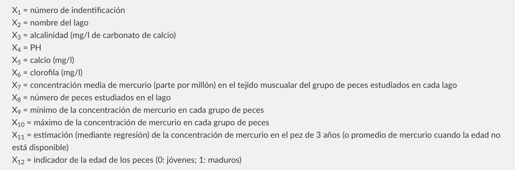

```
(53, 12)
```

# Cálculo de medias estadísticas

## Variables cuantitativas

|  | X3 | X4 | X5 | X6 | X7 | X8 | X9 | X10 | X11 | X12 |
| --- | --- | --- | --- | --- | --- | --- | --- | --- | --- | --- |
| count | 53.000000 | 53.000000 | 53.000000 | 53.000000 | 53.000000 | 53.000000 | 53.000000 | 53.000000 | 53.000000 | 53.000000 |
| mean | 37.530189 | 6.590566 | 22.201887 | 23.116981 | 0.527170 | 13.056604 | 0.279811 | 0.874528 | 0.513208 | 0.811321 |
| std | 38.203527 | 1.288449 | 24.932574 | 30.816321 | 0.341036 | 8.560677 | 0.226406 | 0.522047 | 0.338729 | 0.394998 |
| min | 1.200000 | 3.600000 | 1.100000 | 0.700000 | 0.040000 | 4.000000 | 0.040000 | 0.060000 | 0.040000 | 0.000000 |
| 25% | 6.600000 | 5.800000 | 3.300000 | 4.600000 | 0.270000 | 10.000000 | 0.090000 | 0.480000 | 0.250000 | 1.000000 |
| 50% | 19.600000 | 6.800000 | 12.600000 | 12.800000 | 0.480000 | 12.000000 | 0.250000 | 0.840000 | 0.450000 | 1.000000 |
| 75% | 66.500000 | 7.400000 | 35.600000 | 24.700000 | 0.770000 | 12.000000 | 0.330000 | 1.330000 | 0.700000 | 1.000000 |
| max | 128.000000 | 9.100000 | 90.700000 | 152.400000 | 1.330000 | 44.000000 | 0.920000 | 2.040000 | 1.530000 | 1.000000 |

#### Varianza de variables cuantitativas

```
Alcalinidad                1459.5094557329464
PH                         1.6601015965166905
Calcio                     621.6332656023222
Clorofila                  949.6456676342525
Concentracion Mid Hg       0.11630529753265603
Num Peces Lago             73.28519593613936
Min Concentracion Hg       0.05125957910014513
Max Concentracion Hg       0.27253294629898406
Concentracion Hg 3 Years   0.1147375907111756
```

#### Moda de variables cuantitativas

```
Moda
Repeticiones   Valor
2              17.3
4              5.8
2              3
3              1.6
4              0.34
20             12
6              0.04
2              0.06
4              0.16
43             1
```

## Variables cualitativas

#### Moda de variables cualitativas

```
Nombre Lago

0             Alligator
1                 Annie
2                Apopka
3          Blue Cypress
4                 Brick
5                Bryant
6                Cherry
7              Crescent
8            Deer Point
9                  Dias
10                 Dorr
11                 Down
12    East Tohopekaliga
```

[output cut: 45 more lines]

### Tablas de distribución de frecuencias

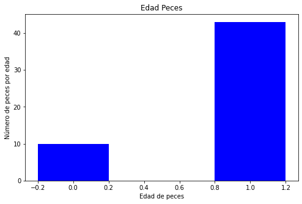

```
~~~ Nombre Lago ~~~
Alligator            1
Louisa               1
Minneola             1
Monroe               1
Newmans              1
Ocean Pond           1
Ocheese Pond         1
Okeechobee           1
Orange               1
Panasoffkee          1
Parker               1
Placid               1
Puzzle               1
Rodman               1
Rousseau             1
Sampson              1
Shipp                1
Talquin              1
Tarpon               1
Tohopekaliga         1
Trafford             1
Trout                1
Tsala Apopka         1
Weir                 1
Wildcat              1
Miccasukee           1
Lochloosa            1
Annie                1
Kissimmee            1
Apopka               1
Blue Cypress         1
Brick                1
Bryant               1
Cherry               1
Crescent             1
Deer Point           1
Dias                 1
Dorr                 1
Down                 1
Eaton                1
East Tohopekaliga    1
Farm-13              1
George               1
Griffin              1
Harney               1
Hart                 1
Hatchineha           1
Iamonia              1
Istokpoga            1
Jackson              1
Josephine            1
Kingsley             1
Yale                 1
Name: X2, dtype: int64


~~~ Edad Peces ~~~
1    43
0    10
Name: X12, dtype: int64
```

## Valores nulos

Al dentificar cantidad de valores nulos en dataset observamos que no hay valores nulos.

```
X1     0
X2     0
X3     0
X4     0
X5     0
X6     0
X7     0
X8     0
X9     0
X10    0
X11    0
X12    0
dtype: int64
```

#### Identificar los nombres de los lagos (Valores únicos)

#### Podemos observar que cada fila corresponde a 1 lago, no hay datos repetidos para cada lago

```
53
```

# Explora los datos usando herramientas de visualización

## Variables categóricas

```
 [Text(-0.9123463061021291, 0.614511365022487, 'Maduros'),
 [Text(-0.49764343969207037, 0.33518801728499287, '81%'),
```

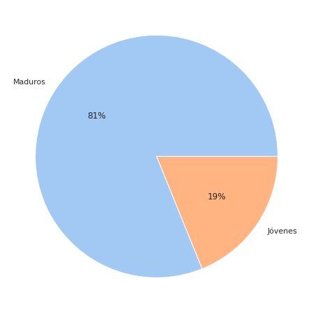

## Variables Cuantitativas

Podemos observar un scatter matrix, el cual nos permite ver de manera visual cómo se comportan los datos y cómo se relacionan entre sí. Por ejemplo, vemos cómo X7 tiene una línea de tendencia con X9, X10 y X11.

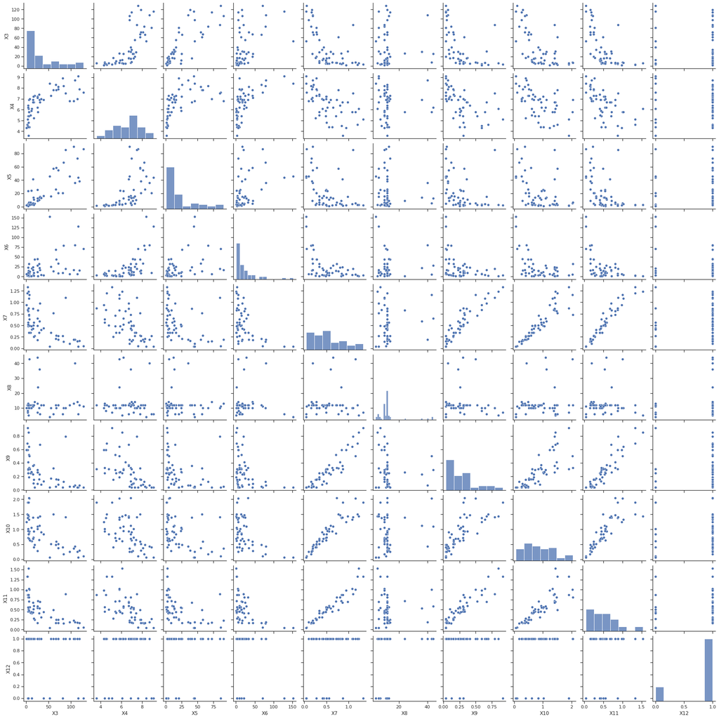

## Correlación entre variables

A continuación, podemos observar una matriz de correlación, que nos permite anazlizar la correlación entre variables. Esta nos permitirá encontrar las variables que mejor se ajusten para generar un modelo.

> En este caso, como mencioné anteriormente, X9, X10 y X11 son las variables que mayor correlación tienen con X7, por lo que para elegir una de las 3 y evitar colinealidad, analizamos la correlación que tiene cada una con las otras variables, y se determinó que X9 es la mejor opción, pues tiene baja correlación con las demás variables, lo que puede mejorar nuestro modelo.

> Por lo tanto, se eligieron X9, X12, X8, X6 y X5 como variables independendientes.

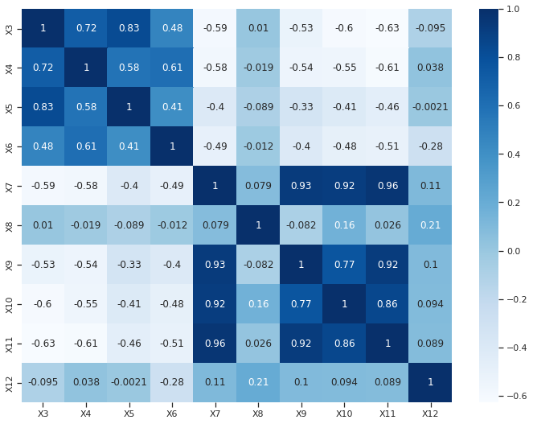

### Medidas de posición

A continuación, podemos observar los boxplots de cada una de nuestras variables, donde se pueden apreciar los cuartiles, el rango intercuartílico, así como nuestros datos atípicos.

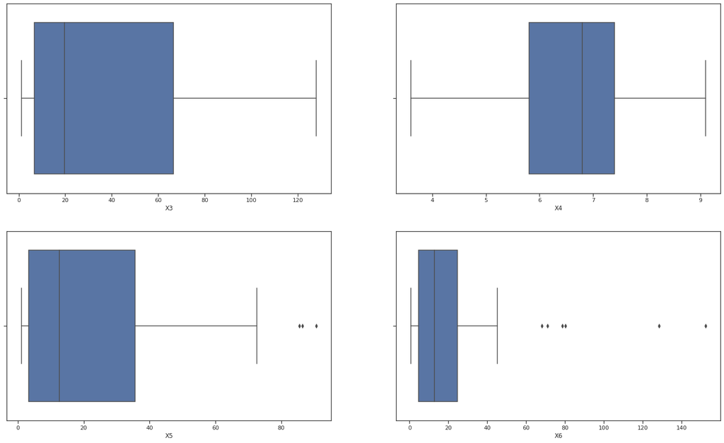

|  | X6 | X8 | X9 |
| --- | --- | --- | --- |
| 0 | 0.7 | 5 | 0.85 |
| 1 | 3.2 | 7 | 0.92 |
| 2 | 128.3 | 6 | 0.04 |
| 3 | 3.5 | 12 | 0.13 |
| 4 | 1.8 | 12 | 0.69 |

### Creación del modelo

#### Modelo 1

En primera instancia, creamos un modelo con las variables mencionadas anteriormente. Analizamos los resultados, y vemos que no existe evidencia para determinar que X12 y X5 producen un efecto significativo en nuestro modelo; por lo tanto las eliminamos.

```
                            OLS Regression Results
==============================================================================
Dep. Variable:                     X7   R-squared:                       0.903
Model:                            OLS   Adj. R-squared:                  0.893
Method:                 Least Squares   F-statistic:                     87.60
Date:                Mon, 19 Sep 2022   Prob (F-statistic):           1.21e-22
Time:                        02:45:26   Log-Likelihood:                 44.168
No. Observations:                  53   AIC:                            -76.34
Df Residuals:                      47   BIC:                            -64.51
Df Model:                           5
Covariance Type:            nonrobust
==============================================================================
                 coef    std err          t      P>|t|      [0.025      0.975]
------------------------------------------------------------------------------
Intercept      0.1585      0.054      2.917      0.005       0.049       0.268
X5            -0.0005      0.001     -0.756      0.453      -0.002       0.001
X6            -0.0015      0.001     -2.490      0.016      -0.003      -0.000
X8             0.0062      0.002      3.308      0.002       0.002       0.010
X9             1.3216      0.077     17.212      0.000       1.167       1.476
X12           -0.0438      0.042     -1.034      0.306      -0.129       0.041
==============================================================================
Omnibus:                        6.384   Durbin-Watson:                   2.000
Prob(Omnibus):                  0.041   Jarque-Bera (JB):                6.166
Skew:                           0.835   Prob(JB):                       0.0458
Kurtosis:                       2.968   Cond. No.                         261.
==============================================================================

Notes:
[1] Standard Errors assume that the covariance matrix of the errors is correctly specified.
```

#### Modelo 2

Repetimos el mismo paso, esta vez utilzando solamente 3 variables; X6, X8 y X9.

```
                            OLS Regression Results
==============================================================================
Dep. Variable:                     X7   R-squared:                       0.899
Model:                            OLS   Adj. R-squared:                  0.893
Method:                 Least Squares   F-statistic:                     145.5
Date:                Mon, 19 Sep 2022   Prob (F-statistic):           2.12e-24
Time:                        02:45:26   Log-Likelihood:                 43.097
No. Observations:                  53   AIC:                            -78.19
Df Residuals:                      49   BIC:                            -70.31
Df Model:                           3
Covariance Type:            nonrobust
==============================================================================
                 coef    std err          t      P>|t|      [0.025      0.975]
------------------------------------------------------------------------------
Intercept      0.1107      0.042      2.657      0.011       0.027       0.194
X6            -0.0015      0.001     -2.724      0.009      -0.003      -0.000
X8             0.0060      0.002      3.285      0.002       0.002       0.010
X9             1.3336      0.075     17.798      0.000       1.183       1.484
==============================================================================
Omnibus:                        6.105   Durbin-Watson:                   1.943
Prob(Omnibus):                  0.047   Jarque-Bera (JB):                6.020
Skew:                           0.822   Prob(JB):                       0.0493
Kurtosis:                       2.844   Cond. No.                         207.
==============================================================================

Notes:
[1] Standard Errors assume that the covariance matrix of the errors is correctly specified.
```

```
'\nX2 = sm.add_constant(X)\nest2 = sm.OLS(y, X2).fit()\nprint(est2.summary())\n'
```

#### Distribución de variables

Como podemos observar, nuestras variables no tienen una distribución normal, por lo que no podemos explicar los efectos de mercurio en la saludo humana con el modelo generado. Las 3 tienen un sesgo a la derecha.

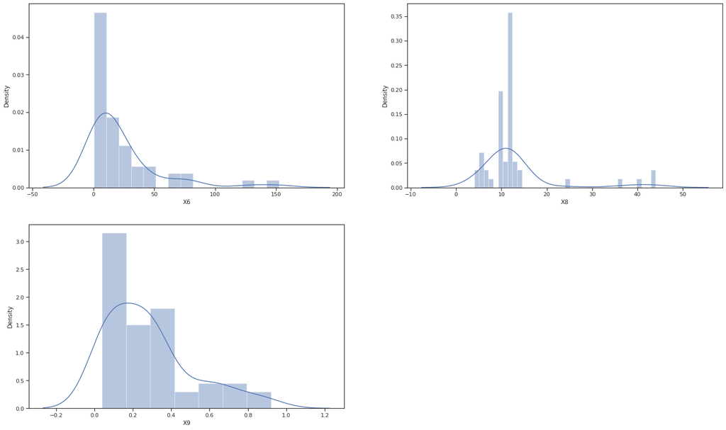

### Transformación de datos

Al observar que prácticamente todas nuestras distribuciones tienen un sesgo positivo, se aplicará una transformación logarítmica para normalizar la distribución de datos. Esto nos permitirá generar un mejor modelo.

#### Boxplots

A continuación, podemos ver los boxplots de nuestras variables independientes, y vemos la gran cantidad de datos atípicos que contiene X8, lo que también puede afectar los resultados del modelo.

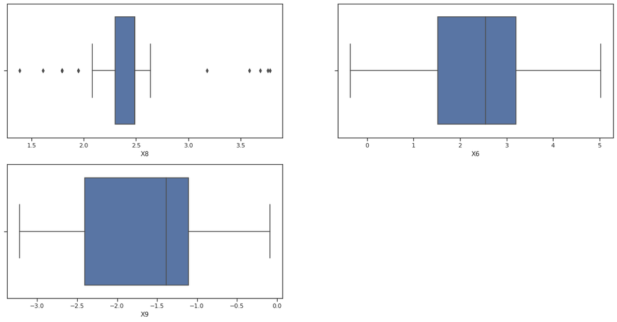

#### Normalización

Una vez se aplicó la función logarítmica, podemos ver cómo prácticamente desapareció el sesgo en las tres.

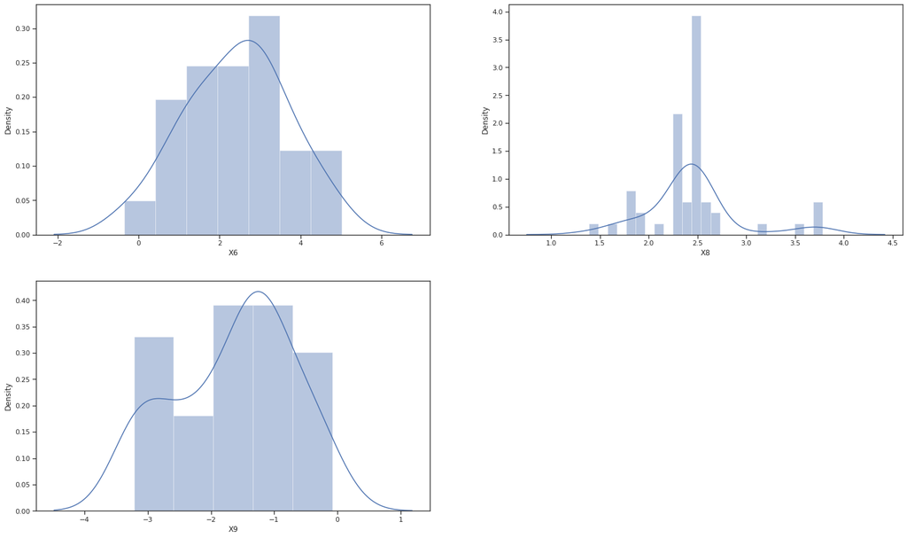

```
X6
X8
X9
```

|  | X1 | X2 | X3 | X4 | X5 | X6 | X7 | X8 | X9 | X10 | X11 | X12 |
| --- | --- | --- | --- | --- | --- | --- | --- | --- | --- | --- | --- | --- |
| 0 | 1 | Alligator | 5.9 | 6.1 | 3.0 | 0.7 | 1.23 | 5 | 0.85 | 1.43 | 1.53 | 1 |
| 1 | 2 | Annie | 3.5 | 5.1 | 1.9 | 3.2 | 1.33 | 7 | 0.92 | 1.90 | 1.33 | 0 |
| 2 | 3 | Apopka | 116.0 | 9.1 | 44.1 | 128.3 | 0.04 | 6 | 0.04 | 0.06 | 0.04 | 0 |
| 3 | 4 | Blue Cypress | 39.4 | 6.9 | 16.4 | 3.5 | 0.44 | 12 | 0.13 | 0.84 | 0.44 | 0 |
| 4 | 5 | Brick | 2.5 | 4.6 | 2.9 | 1.8 | 1.20 | 12 | 0.69 | 1.50 | 1.33 | 1 |
| 5 | 6 | Bryant | 19.6 | 7.3 | 4.5 | 44.1 | 0.27 | 14 | 0.04 | 0.48 | 0.25 | 1 |
| 6 | 7 | Cherry | 5.2 | 5.4 | 2.8 | 3.4 | 0.48 | 10 | 0.30 | 0.72 | 0.45 | 1 |
| 7 | 8 | Crescent | 71.4 | 8.1 | 55.2 | 33.7 | 0.19 | 12 | 0.08 | 0.38 | 0.16 | 1 |
| 8 | 9 | Deer Point | 26.4 | 5.8 | 9.2 | 1.6 | 0.83 | 24 | 0.26 | 1.40 | 0.72 | 1 |
| 9 | 10 | Dias | 4.8 | 6.4 | 4.6 | 22.5 | 0.81 | 12 | 0.41 | 1.47 | 0.81 | 1 |
| 10 | 11 | Dorr | 6.6 | 5.4 | 2.7 | 14.9 | 0.71 | 12 | 0.52 | 0.86 | 0.71 | 1 |
| 11 | 12 | Down | 16.5 | 7.2 | 13.8 | 4.0 | 0.50 | 12 | 0.10 | 0.73 | 0.51 | 1 |
| 12 | 13 | Eaton | 25.4 | 7.2 | 25.2 | 11.6 | 0.49 | 7 | 0.26 | 1.01 | 0.54 | 1 |
| 13 | 14 | East Tohopekaliga | 7.1 | 5.8 | 5.2 | 5.8 | 1.16 | 43 | 0.50 | 2.03 | 1.00 | 1 |
| 14 | 15 | Farm-13 | 128.0 | 7.6 | 86.5 | 71.1 | 0.05 | 11 | 0.04 | 0.11 | 0.05 | 0 |
| 15 | 16 | George | 83.7 | 8.2 | 66.5 | 78.6 | 0.15 | 10 | 0.12 | 0.18 | 0.15 | 1 |
| 16 | 17 | Griffin | 108.5 | 8.7 | 35.6 | 80.1 | 0.19 | 40 | 0.07 | 0.43 | 0.19 | 1 |
| 17 | 18 | Harney | 61.3 | 7.8 | 57.4 | 13.9 | 0.77 | 6 | 0.32 | 1.50 | 0.49 | 1 |
| 18 | 19 | Hart | 6.4 | 5.8 | 4.0 | 4.6 | 1.08 | 10 | 0.64 | 1.33 | 1.02 | 1 |
| 19 | 20 | Hatchineha | 31.0 | 6.7 | 15.0 | 17.0 | 0.98 | 6 | 0.67 | 1.44 | 0.70 | 1 |
| 20 | 21 | Iamonia | 7.5 | 4.4 | 2.0 | 9.6 | 0.63 | 12 | 0.33 | 0.93 | 0.45 | 1 |
| 21 | 22 | Istokpoga | 17.3 | 6.7 | 10.7 | 9.5 | 0.56 | 12 | 0.37 | 0.94 | 0.59 | 1 |
| 22 | 23 | Jackson | 12.6 | 6.1 | 3.7 | 21.0 | 0.41 | 12 | 0.25 | 0.61 | 0.41 | 0 |
| 23 | 24 | Josephine | 7.0 | 6.9 | 6.3 | 32.1 | 0.73 | 12 | 0.33 | 2.04 | 0.81 | 1 |
| 24 | 25 | Kingsley | 10.5 | 5.5 | 6.3 | 1.6 | 0.34 | 10 | 0.25 | 0.62 | 0.42 | 1 |
| 25 | 26 | Kissimmee | 30.0 | 6.9 | 13.9 | 21.5 | 0.59 | 36 | 0.23 | 1.12 | 0.53 | 1 |
| 26 | 27 | Lochloosa | 55.4 | 7.3 | 15.9 | 24.7 | 0.34 | 10 | 0.17 | 0.52 | 0.31 | 1 |
| 27 | 28 | Louisa | 3.9 | 4.5 | 3.3 | 7.0 | 0.84 | 8 | 0.59 | 1.38 | 0.87 | 1 |
| 28 | 29 | Miccasukee | 5.5 | 4.8 | 1.7 | 14.8 | 0.50 | 11 | 0.31 | 0.84 | 0.50 | 0 |
| 29 | 30 | Minneola | 6.3 | 5.8 | 3.3 | 0.7 | 0.34 | 10 | 0.19 | 0.69 | 0.47 | 1 |
| 30 | 31 | Monroe | 67.0 | 7.8 | 58.6 | 43.8 | 0.28 | 10 | 0.16 | 0.59 | 0.25 | 1 |
| 31 | 32 | Newmans | 28.8 | 7.4 | 10.2 | 32.7 | 0.34 | 10 | 0.16 | 0.65 | 0.41 | 1 |
| 32 | 33 | Ocean Pond | 5.8 | 3.6 | 1.6 | 3.2 | 0.87 | 12 | 0.31 | 1.90 | 0.87 | 0 |
| 33 | 34 | Ocheese Pond | 4.5 | 4.4 | 1.1 | 3.2 | 0.56 | 13 | 0.25 | 1.02 | 0.56 | 0 |
| 34 | 35 | Okeechobee | 119.1 | 7.9 | 38.4 | 16.1 | 0.17 | 12 | 0.07 | 0.30 | 0.16 | 1 |
| 35 | 36 | Orange | 25.4 | 7.1 | 8.8 | 45.2 | 0.18 | 13 | 0.09 | 0.29 | 0.16 | 1 |
| 36 | 37 | Panasoffkee | 106.5 | 6.8 | 90.7 | 16.5 | 0.19 | 13 | 0.05 | 0.37 | 0.23 | 1 |
| 37 | 38 | Parker | 53.0 | 8.4 | 45.6 | 152.4 | 0.04 | 4 | 0.04 | 0.06 | 0.04 | 0 |
| 38 | 39 | Placid | 8.5 | 7.0 | 2.5 | 12.8 | 0.49 | 12 | 0.31 | 0.63 | 0.56 | 1 |
| 39 | 40 | Puzzle | 87.6 | 7.5 | 85.5 | 20.1 | 1.10 | 10 | 0.79 | 1.41 | 0.89 | 1 |
| 40 | 41 | Rodman | 114.0 | 7.0 | 72.6 | 6.4 | 0.16 | 14 | 0.04 | 0.26 | 0.18 | 1 |
| 41 | 42 | Rousseau | 97.5 | 6.8 | 45.5 | 6.2 | 0.10 | 12 | 0.05 | 0.26 | 0.19 | 1 |
| 42 | 43 | Sampson | 11.8 | 5.9 | 24.2 | 1.6 | 0.48 | 10 | 0.27 | 1.05 | 0.44 | 1 |
| 43 | 44 | Shipp | 66.5 | 8.3 | 26.0 | 68.2 | 0.21 | 12 | 0.05 | 0.48 | 0.16 | 1 |
| 44 | 45 | Talquin | 16.0 | 6.7 | 41.2 | 24.1 | 0.86 | 12 | 0.36 | 1.40 | 0.67 | 1 |
| 45 | 46 | Tarpon | 5.0 | 6.2 | 23.6 | 9.6 | 0.52 | 12 | 0.31 | 0.95 | 0.55 | 1 |
| 46 | 51 | Tohopekaliga | 25.6 | 6.2 | 12.6 | 27.7 | 0.65 | 44 | 0.30 | 1.10 | 0.58 | 1 |
| 47 | 47 | Trafford | 81.5 | 8.9 | 20.5 | 9.6 | 0.27 | 6 | 0.04 | 0.40 | 0.27 | 0 |
| 48 | 48 | Trout | 1.2 | 4.3 | 2.1 | 6.4 | 0.94 | 10 | 0.59 | 1.24 | 0.98 | 1 |
| 49 | 49 | Tsala Apopka | 34.0 | 7.0 | 13.1 | 4.6 | 0.40 | 12 | 0.08 | 0.90 | 0.31 | 1 |
| 50 | 50 | Weir | 15.5 | 6.9 | 5.2 | 16.5 | 0.43 | 11 | 0.23 | 0.69 | 0.43 | 1 |
| 51 | 52 | Wildcat | 17.3 | 5.2 | 3.0 | 2.6 | 0.25 | 12 | 0.15 | 0.40 | 0.28 | 1 |
| 52 | 53 | Yale | 71.8 | 7.9 | 20.5 | 8.8 | 0.27 | 12 | 0.15 | 0.51 | 0.25 | 1 |

### Prueba de modelo 2

Una vez hayamos realizado las modificaciones necesarias a nuestros datos para limpiarlos, volvemos a correr nuestro modelo, para ver el impacto que esto tuvo en el, y si es necesario realizar cambios.

> Como podemos observar, nuestro modelo cambió bastante, podemos ver como las variables X6 y X8 no generan un impacto significativo en nuestro modelo. Además, nuestra R cuadrada ajustada disminuyó. Esta variable explica la manera en la que nuestro modelo se ajusta a los datos.

```
                            OLS Regression Results
==============================================================================
Dep. Variable:                     X7   R-squared:                       0.790
Model:                            OLS   Adj. R-squared:                  0.777
Method:                 Least Squares   F-statistic:                     61.40
Date:                Mon, 19 Sep 2022   Prob (F-statistic):           1.27e-16
Time:                        02:45:28   Log-Likelihood:                 23.660
No. Observations:                  53   AIC:                            -39.32
Df Residuals:                      49   BIC:                            -31.44
Df Model:                           3
Covariance Type:            nonrobust
==============================================================================
                 coef    std err          t      P>|t|      [0.025      0.975]
------------------------------------------------------------------------------
Intercept      1.0314      0.126      8.161      0.000       0.777       1.285
X6            -0.0210      0.020     -1.073      0.289      -0.060       0.018
X8             0.0234      0.048      0.491      0.626      -0.072       0.119
X9             0.3110      0.027     11.588      0.000       0.257       0.365
==============================================================================
Omnibus:                        6.674   Durbin-Watson:                   1.661
Prob(Omnibus):                  0.036   Jarque-Bera (JB):                2.439
Skew:                           0.100   Prob(JB):                        0.295
Kurtosis:                       1.968   Cond. No.                         24.7
==============================================================================

Notes:
[1] Standard Errors assume that the covariance matrix of the errors is correctly specified.
```

#### Modelo 3

Una vez realizado el análisis anterior, determinamos que la variable X9 es la que mejor describe nuestra variable dependiente, por lo que nuestro modelo de regresión lineal múltiple se convierte en un modelo de regresión lineal simple. Podemos ver cómo incrementó nuestro R-cuadrado ajustado con respecto al modelo anterior.

```
                            OLS Regression Results
==============================================================================
Dep. Variable:                     X7   R-squared:                       0.784
Model:                            OLS   Adj. R-squared:                  0.780
Method:                 Least Squares   F-statistic:                     185.2
Date:                Mon, 19 Sep 2022   Prob (F-statistic):           1.32e-18
Time:                        02:45:28   Log-Likelihood:                 22.935
No. Observations:                  53   AIC:                            -41.87
Df Residuals:                      51   BIC:                            -37.93
Df Model:                           1
Covariance Type:            nonrobust
==============================================================================
                 coef    std err          t      P>|t|      [0.025      0.975]
------------------------------------------------------------------------------
Intercept      1.0587      0.045     23.621      0.000       0.969       1.149
X9             0.3238      0.024     13.608      0.000       0.276       0.372
==============================================================================
Omnibus:                        7.162   Durbin-Watson:                   1.695
Prob(Omnibus):                  0.028   Jarque-Bera (JB):                2.928
Skew:                           0.260   Prob(JB):                        0.231
Kurtosis:                       1.973   Cond. No.                         4.71
==============================================================================

Notes:
[1] Standard Errors assume that the covariance matrix of the errors is correctly specified.
```

### Prueba de modelo 3

A continuación, una vez generado nuestro modelo, podemos generar las predicciones de X7, nuestra variable dependiente. Posteriormente, obtenemos los residuos.

### Residuos

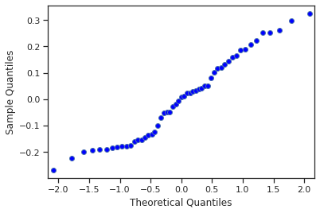

```
ShapiroResult(statistic=0.9524779319763184, pvalue=0.03442264720797539)
```

## Anova

Tenemos nuestra variable categórica X12, que es un indicador de la edad de los peces. Para responder a la siguiente pregunta:

> ¿Habrá diferencia significativa entre la concentración de mercurio por la edad de los peces?

Podemos concluir que no existe una diferencia significativa entre ambos grupos de edad de peces, pues tenemos un valor-p que supera 0.05.

|  | sum_sq | df | F | PR(>F) |
| --- | --- | --- | --- | --- |
| X12 | 0.071511 | 1.0 | 0.610248 | 0.438306 |
| Residual | 5.976364 | 51.0 | NaN | NaN |

# Conclusiones

> ¿Cuáles son los principales factores que influyen en el nivel de contaminación por mercurio en los peces de los lagos de Florida?